# Spatial Transformer Example with Cluttered MNIST

[figure not shown]

Image Source: https://www.pinterest.com/sadieziegler123/bumblebee-3/

1 Spatial Transformer Example with Cluttered MNIST

1.1 About Notebook

2 Part 1: Set-up

2.1 Load APIs

2.2 Load data

2.3 Turn labels from dense to one hot representation

3 Part 2: Problem

4 Part 3: Localization Network

4.1 Create placeholders

4.2 Reshape inputs

4.3 Setup a two-layer localisation network

4.4 Define a two layer localisation network

4.5 Create a spatial transformer module

5 Part 4: Convolutional Layers

5.1 Build the first layer of convolution

5.2 Build the second layer of convolution

5.3 Connect the convolutional layers with a fully-connected layer

5.4 Add a softmax layer for predicted probabilities

6 Part 5: Loss, Optimization, and Evalution

6.1 Define loss and optimizer

6.2 Monitor accuracy

7 Part 6: Create and Run Session

7.1 Initialize session

7.2 Train parameters

7.3 Train model

8 Part 7: Evaluate

8.1 Accuracy

8.2 Inspect results

## About Notebook

**Orginal Source:** https://github.com/tensorflow/models/blob/master/transformer/cluttered_mnist.py

**Goal:** Demonstrate spatial transformer networks use case with tensorflow.

**Actions:**

- Re-annotate orginal source for easier consumption.
- Include visual represention of inputs and predictions.
- Blog about [experience](https://medium.com/wonks-this-way/spatial-transformer-networks-with-tensorflow-2eaed0374a16#.2emq15acn).

**Audience:** Intermediate level Tensorflow users.

# Part 1: Set-up

## Load APIs

```python
import tensorflow as tf
from spatial_transformer import transformer
import numpy as np
from tf_utils import weight_variable, bias_variable, dense_to_one_hot
import matplotlib.pylab as plt
from datetime import datetime
%matplotlib inline
```

## Load data

```python
mnist_cluttered = np.load('./data/mnist_sequence1_sample_5distortions5x5.npz')

X_train = mnist_cluttered['X_train']
y_train = mnist_cluttered['y_train']
X_valid = mnist_cluttered['X_valid']
y_valid = mnist_cluttered['y_valid']
X_test = mnist_cluttered['X_test']
y_test = mnist_cluttered['y_test']
```

## Turn labels from dense to one hot representation

```python
Y_train = dense_to_one_hot(y_train, n_classes=10)
Y_valid = dense_to_one_hot(y_valid, n_classes=10)
Y_test = dense_to_one_hot(y_test, n_classes=10)
```

# Part 2: Problem

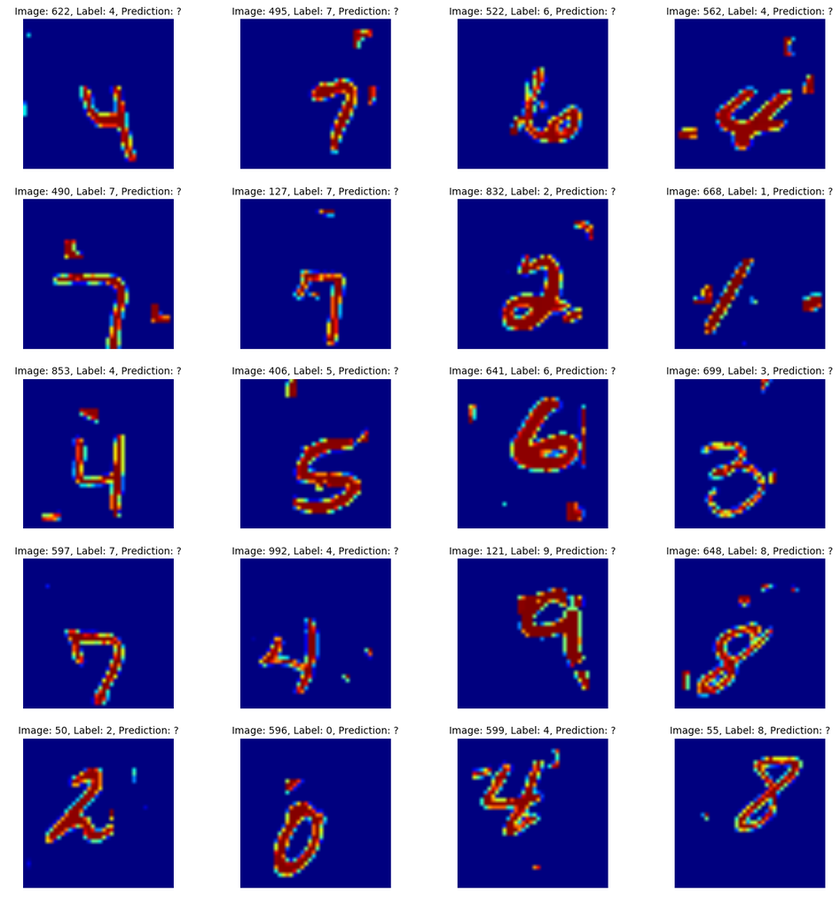

```python
np.random.seed = 99
example_indices = np.random.randint(1, 1000, size=20)

ith = 0
plt.rcParams['figure.figsize'] = (16.0, 16.0)
plt.subplots_adjust(wspace=0, hspace=.2)
for index in example_indices:

    plt.subplot(5, 4, ith+1)
    plt.imshow(mnist_cluttered['X_test'].reshape(1000, 40, 40)[index, ...])

    truth = mnist_cluttered['y_test'][index][0]

    plt.title("Image: {}, Label: {}, Prediction: ?".format(index, truth), {'fontsize': 10})
    plt.axis('off')
    ith += 1
```

# Part 3: Localization Network

## Create placeholders

**Key idea:**

Placeholders for 40x40 resolution input images.

```python
tf.set_random_seed(1)
x = tf.placeholder(tf.float32, [None, 1600])
y = tf.placeholder(tf.float32, [None, 10])
```

## Reshape inputs

**Key idea:**

Since x is currently [batch, height*width], we need to reshape to a 4-D tensor to use it in a convolutional graph. If one component of `shape` is the special value -1, the size of that dimension is computed so that the total size remains constant. Since we haven't defined the batch dimension's shape yet, we use -1 to denote this dimension should not change size.

```python
x_tensor = tf.reshape(x, [-1, 40, 40, 1])
```

## Setup a two-layer localisation network

**Key idea:**

Setup the two-layer localisation network to figure out the parameters for an affine transformation of the input. Use identity transformation as starting point.

```python
# Identity transformation
initial = np.array([[1., 0, 0], [0, 1., 0]])
initial = initial.astype('float32')
initial = initial.flatten()

# Create variables for fully connected layer for the localisation network
W_fc_loc1 = weight_variable([1600, 20])
b_fc_loc1 = bias_variable([20])

W_fc_loc2 = weight_variable([20, 6])
b_fc_loc2 = tf.Variable(initial_value=initial, name='b_fc_loc2')
```

## Define a two layer localisation network

**Key idea:**

Use activation function (Tanh) for first and second local layers. Add regularization technique (dropout) in anticipation for overfitting.

```python
# Frist layer
h_fc_loc1 = tf.nn.tanh(tf.matmul(x, W_fc_loc1) + b_fc_loc1)

# Dropout for regularization
keep_prob = tf.placeholder(tf.float32)
h_fc_loc1_drop = tf.nn.dropout(h_fc_loc1, keep_prob)

# Second layer
h_fc_loc2 = tf.nn.tanh(tf.matmul(h_fc_loc1_drop, W_fc_loc2) + b_fc_loc2)
```

## Create a spatial transformer module

```python
out_size = (40, 40)
h_trans = transformer(x_tensor, h_fc_loc2, out_size)
```

# Part 4: Convolutional Layers

**Key idea:**

Design a simple two layer convolutional network. This arbitrary, so you can experiment with different structures!

## Build the first layer of convolution

**Key idea:**

Define our stride as batch x height x width x channels instead of pooling, we use strides of 2 and more layers with smaller filters.

```python
# Weight matrix is [height x width x input_channels x output_channels]
filter_size = 3
n_filters_1 = 16
W_conv1 = weight_variable([filter_size, filter_size, 1, n_filters_1])

# Bias is [output_channels]
b_conv1 = bias_variable([n_filters_1])

# Activation Function
h_conv1 = tf.nn.relu(
    tf.nn.conv2d(input=h_trans, filter=W_conv1, strides=[1, 2, 2, 1], padding='SAME') + b_conv1)
```

## Build the second layer of convolution

```python
n_filters_2 = 16
W_conv2 = weight_variable([filter_size, filter_size, n_filters_1, n_filters_2])
b_conv2 = bias_variable([n_filters_2])
h_conv2 = tf.nn.relu(
    tf.nn.conv2d(input=h_conv1, filter=W_conv2, strides=[1, 2, 2, 1], padding='SAME') + b_conv2)
```

## Connect the convolutional layers with a fully-connected layer

```python
# Reshape to the fully-connected layer
h_conv2_flat = tf.reshape(h_conv2, [-1, 10 * 10 * n_filters_2])

# Create the fully-connected layer
n_fc = 1024
W_fc1 = weight_variable([10 * 10 * n_filters_2, n_fc])
b_fc1 = bias_variable([n_fc])
h_fc1 = tf.nn.relu(tf.matmul(h_conv2_flat, W_fc1) + b_fc1)

# Add additional regularization
h_fc1_drop = tf.nn.dropout(h_fc1, keep_prob)
```

## Add a softmax layer for predicted probabilities

```python
W_fc2 = weight_variable([n_fc, 10])
b_fc2 = bias_variable([10])
y_logits = tf.matmul(h_fc1_drop, W_fc2) + b_fc2
scores = tf.nn.softmax_cross_entropy_with_logits(logits=y_logits, labels=y)
```

# Part 5: Loss, Optimization, and Evalution

## Define loss and optimizer

```python
# Loss
cross_entropy = tf.reduce_mean(scores)

# Optimizer
opt = tf.train.AdamOptimizer()

# Minimize
optimizer = opt.minimize(cross_entropy)

# Gradients
grads = opt.compute_gradients(cross_entropy, [b_fc_loc2])
```

## Monitor accuracy

```python
predictions = tf.argmax(y_logits, 1)
correct_prediction = tf.equal(tf.argmax(y_logits, 1), tf.argmax(y, 1))
accuracy = tf.reduce_mean(tf.cast(correct_prediction, 'float'))

results_fmt = '[{:%H:%M:%S}] EPOCH {}/{} LOSS {:.3f}, DEV: {:.3f}'
```

# Part 6: Create and Run Session

**Key idea:**

Standard tensorflow boilerplate code to create and run a session.

## Initialize session

```python
sess = tf.Session()
sess.run(tf.global_variables_initializer())
```

## Train parameters

```python
# We'll now train in minibatches and report accuracy, loss:
iter_per_epoch = 100
n_epochs = 20 # Feel free to increase the epochs for better results
train_size = 10000

indices = np.linspace(0, 10000 - 1, iter_per_epoch)
indices = indices.astype('int')
```

## Train model

```python
results_fmt = '[{:%H:%M:%S}] EPOCH {}, ITERATION {}/{}, LOSS {:.3f}'

for epoch_i in range(n_epochs):
    for iter_i in range(iter_per_epoch - 1):
        batch_xs = X_train[indices[iter_i]:indices[iter_i + 1]]
        batch_ys = Y_train[indices[iter_i]:indices[iter_i + 1]]

        if iter_i % 10 == 0:
            loss = sess.run(cross_entropy, feed_dict={x: batch_xs, y: batch_ys, keep_prob: 1.0})
            print(results_fmt.format(datetime.now(), epoch_i, iter_i, iter_per_epoch, loss))

        sess.run(optimizer, feed_dict={x: batch_xs, y: batch_ys, keep_prob: 0.8})

    val_acc = sess.run(accuracy, feed_dict={x: X_valid, y: Y_valid, keep_prob: 1.0})

    print('--------> {}/{} EPOCHS, VAL ACC: {:.3f}'.format(epoch_i + 1, n_epochs, val_acc))

test_acc, test_predictions = sess.run([accuracy, predictions], feed_dict={x: X_test, y: Y_test, keep_prob: 1.0})
#     theta = sess.run(h_fc_loc2, feed_dict={x: batch_xs, keep_prob: 1.0})
#     print(theta[0])
```

```
[10:59:25] EPOCH 0, ITERATION 0/100, LOSS 2.302
[10:59:25] EPOCH 0, ITERATION 10/100, LOSS 2.300
[10:59:26] EPOCH 0, ITERATION 20/100, LOSS 2.296
[10:59:26] EPOCH 0, ITERATION 30/100, LOSS 2.302
[10:59:27] EPOCH 0, ITERATION 40/100, LOSS 2.299
[10:59:27] EPOCH 0, ITERATION 50/100, LOSS 2.287
[10:59:28] EPOCH 0, ITERATION 60/100, LOSS 2.288
[10:59:29] EPOCH 0, ITERATION 70/100, LOSS 2.239
[10:59:29] EPOCH 0, ITERATION 80/100, LOSS 2.227
[10:59:30] EPOCH 0, ITERATION 90/100, LOSS 2.151
--------> 1/20 EPOCHS, VAL ACC: 0.242
[10:59:30] EPOCH 1, ITERATION 0/100, LOSS 2.079
[10:59:31] EPOCH 1, ITERATION 10/100, LOSS 2.000
[10:59:31] EPOCH 1, ITERATION 20/100, LOSS 1.845
[10:59:32] EPOCH 1, ITERATION 30/100, LOSS 1.727
[10:59:33] EPOCH 1, ITERATION 40/100, LOSS 1.548
[10:59:33] EPOCH 1, ITERATION 50/100, LOSS 1.542
[10:59:34] EPOCH 1, ITERATION 60/100, LOSS 1.416
[10:59:34] EPOCH 1, ITERATION 70/100, LOSS 1.391
[10:59:35] EPOCH 1, ITERATION 80/100, LOSS 1.331
[10:59:35] EPOCH 1, ITERATION 90/100, LOSS 0.958
--------> 2/20 EPOCHS, VAL ACC: 0.684
[10:59:36] EPOCH 2, ITERATION 0/100, LOSS 1.122
[10:59:37] EPOCH 2, ITERATION 10/100, LOSS 0.978
[10:59:37] EPOCH 2, ITERATION 20/100, LOSS 0.856
[10:59:38] EPOCH 2, ITERATION 30/100, LOSS 0.762
[10:59:38] EPOCH 2, ITERATION 40/100, LOSS 0.672
[10:59:39] EPOCH 2, ITERATION 50/100, LOSS 0.810
[10:59:39] EPOCH 2, ITERATION 60/100, LOSS 0.753
[10:59:40] EPOCH 2, ITERATION 70/100, LOSS 0.674
[10:59:40] EPOCH 2, ITERATION 80/100, LOSS 0.705
[10:59:41] EPOCH 2, ITERATION 90/100, LOSS 0.540
--------> 3/20 EPOCHS, VAL ACC: 0.835
[10:59:42] EPOCH 3, ITERATION 0/100, LOSS 0.632
[10:59:42] EPOCH 3, ITERATION 10/100, LOSS 0.556
[10:59:43] EPOCH 3, ITERATION 20/100, LOSS 0.519
[10:59:43] EPOCH 3, ITERATION 30/100, LOSS 0.455
[10:59:44] EPOCH 3, ITERATION 40/100, LOSS 0.376
[10:59:45] EPOCH 3, ITERATION 50/100, LOSS 0.638
[10:59:45] EPOCH 3, ITERATION 60/100, LOSS 0.521
```

[output cut: 165 more lines]

```
[11:01:16] EPOCH 18, ITERATION 70/100, LOSS 0.136
[11:01:16] EPOCH 18, ITERATION 80/100, LOSS 0.102
[11:01:17] EPOCH 18, ITERATION 90/100, LOSS 0.111
--------> 19/20 EPOCHS, VAL ACC: 0.930
[11:01:17] EPOCH 19, ITERATION 0/100, LOSS 0.130
[11:01:18] EPOCH 19, ITERATION 10/100, LOSS 0.089
[11:01:19] EPOCH 19, ITERATION 20/100, LOSS 0.128
[11:01:19] EPOCH 19, ITERATION 30/100, LOSS 0.099
[11:01:20] EPOCH 19, ITERATION 40/100, LOSS 0.086
[11:01:20] EPOCH 19, ITERATION 50/100, LOSS 0.161
[11:01:21] EPOCH 19, ITERATION 60/100, LOSS 0.175
[11:01:21] EPOCH 19, ITERATION 70/100, LOSS 0.088
[11:01:22] EPOCH 19, ITERATION 80/100, LOSS 0.098
[11:01:23] EPOCH 19, ITERATION 90/100, LOSS 0.104
--------> 20/20 EPOCHS, VAL ACC: 0.932
```

# Part 7: Evaluate

## Accuracy

```python
test_acc, test_predictions = sess.run([accuracy, predictions], feed_dict={x: X_test, y: Y_test, keep_prob: 1.0})
print(test_acc)
```

```
0.931
```

## Inspect results

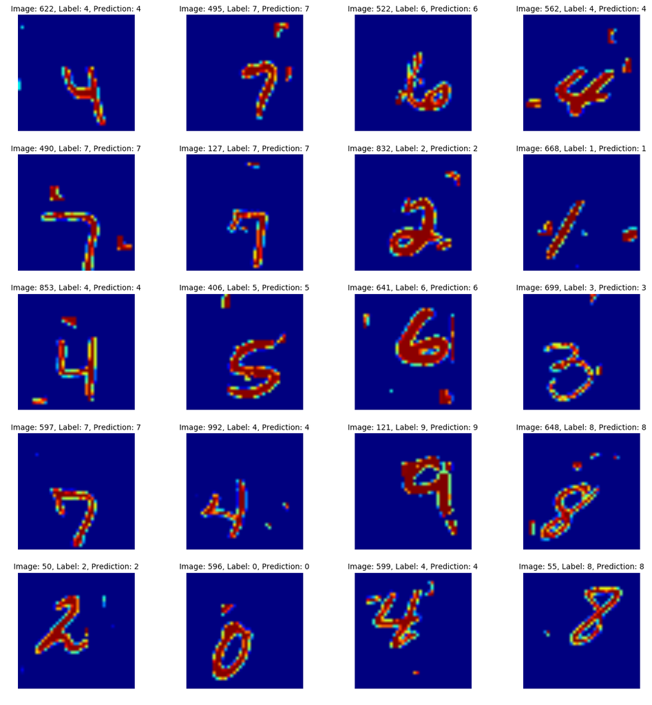

```python
ith = 0
plt.rcParams['figure.figsize'] = (16.0, 16.0)
plt.subplots_adjust(wspace=0, hspace=.2)
for index in example_indices:

    plt.subplot(5, 4, ith+1)
    plt.imshow(mnist_cluttered['X_test'].reshape(1000, 40, 40)[index, ...])

    truth = mnist_cluttered['y_test'][index][0]
    pred = test_predictions[index]

    if truth == pred:
        label_color = 'black'
    else:
        label_color = 'red'

    plt.title("Image: {}, Label: {}, Prediction: {}".format(index, truth, pred), {'fontsize': 10},  color=label_color)
    plt.axis('off')
    ith += 1
```